# Understanding *p* values using a simulations

Using the example of Welch’s independent *t*-test

Ian Hussey

13 March, 2024

```r
library(tidyr)
library(dplyr)
```

```r
library(purrr)
library(ggplot2)
library(knitr)
library(kableExtra)
library(janitor)
```

# Overview of tutorial

This lesson focuses on the distributions of *p* values “under the null hypothesis” (i.e., when the null hypothesis is true, aka when the data generating process is a population model where the effect is zero) and “under the alternative hypothesis” (i.e., when the alternative hypothesis is true, aka when the data generating process is a population model where the effect is non-zero).

Without looking into the math, let’s use simulations to visualise these distributions, in order to understand *p* values better.

# Plotting distributions

In the first lesson, we refreshed our knowledge of distributions and used ggplot to visualise them.

We covered the uniform distribution, where all values between a given range are equally probable, and the normal distribution, which follows a normal (gaussian) bell-shaped distribution.

## Plot uniform distribution

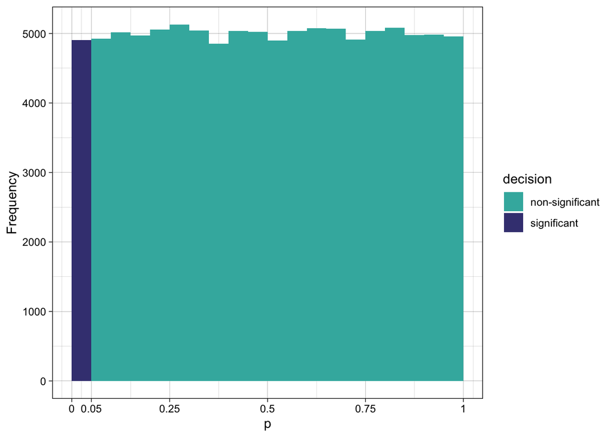

```r
# sample values from a uniform distribution, from the range 0 to 1
tibble(p = runif(n = 100000, min = 0, max = 1)) |>
  # create a decision for each value, with values < .05 labelled as "significant" and those > .05 as "non-significant"
  mutate(decision = ifelse(p < .05, "significant", "non-significant")) |>
  # plot a histogram of these values, with the fill contingent on the the decision
  ggplot(aes(p, fill = decision)) +
  geom_histogram(binwidth = 0.05, boundary = 0) +
  scale_fill_viridis_d(option = "mako", begin = 0.3, end = 0.7, direction = -1) +
  scale_x_continuous(labels = c(0, 0.05, 0.25, 0.50, 0.75, 1.0),
                     breaks = c(0, 0.05, 0.25, 0.50, 0.75, 1.0),
                     limits = c(0, 1)) +
  theme_linedraw() +
  ylab("Frequency")
```

- Note that this plot labels the x axis as *p* values, but the results are not actually *p* values yet: it’s just data drawn from a uniform distribution.

## Plot normal distribution

With the constraint that all values must be within the range [0, 1] to mimic *p* values.

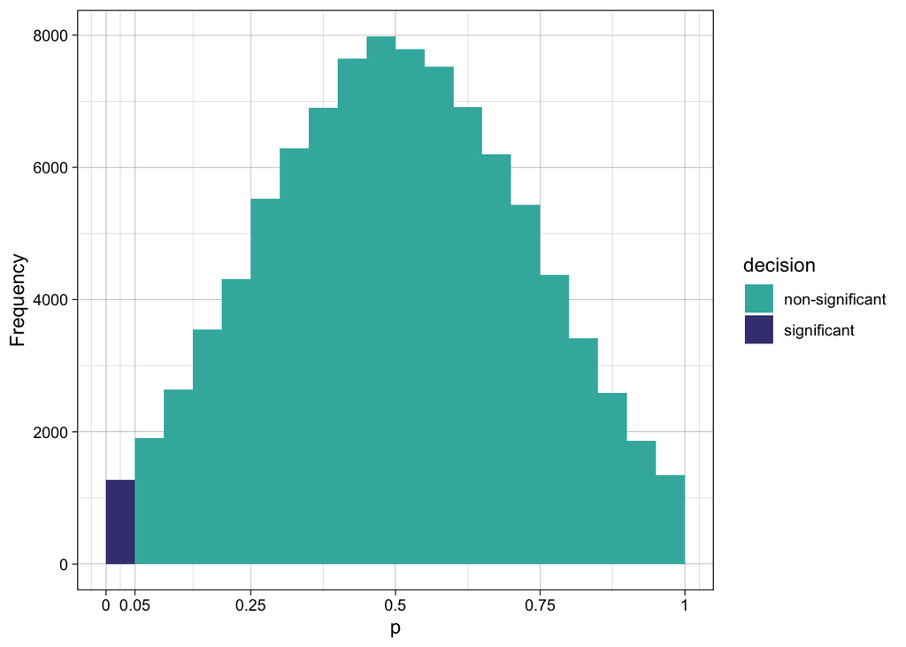

```r
# sample values from a uniform distribution, from the range 0 to 1
tibble(p = rnorm(n = 100000, mean = 0.5, sd = 0.25)) |>
  # drop all values that are outside the range [0, 1] to mimic p values
  filter(p >= 0 & p <= 1) |>
  # create a decision for each value, with values < .05 labelled as "significant" and those > .05 as "non-significant"
  mutate(decision = ifelse(p < .05, "significant", "non-significant")) |>
  # plot a histogram of these values, with the fill contingent on the the decision
  ggplot(aes(p, fill = decision)) +
  geom_histogram(binwidth = 0.05, boundary = 0) +
  scale_fill_viridis_d(option = "mako", begin = 0.3, end = 0.7, direction = -1) +
  scale_x_continuous(labels = c(0, 0.05, 0.25, 0.50, 0.75, 1.0),
                     breaks = c(0, 0.05, 0.25, 0.50, 0.75, 1.0),
                     limits = c(0, 1)) +
  theme_linedraw() +
  ylab("Frequency")
```

- Again, note that this plot labels the x axis as *p* values, but the results are not actually *p* values yet: it’s just data drawn from a normal distribution.

## Coding rule: Don’t repeat yourself / practice writing functions

A key rule when writing code is, in general, *don’t repeat yourself*.

If I want to change the way the above plots are made, or make new ones, I would need to change the code for each one. Equally, if I want do make several more plots like this I would need to repeat the code many times. Every time you copy and paste code like this, it’s another opportunity to make a mistake, eg. to forget to update a parameter somewhere. A good way to avoid this is to write a function to do it for you, and call this function as you need it.

Let’s use this as an opportunity to practice writing functions, as you’ll need to get good at this for the data generation and analysis functions you use in simulations anyway.

Let’s assume that the simulated data is already generated, and that we just want to plot it. I therefore move all the code for plotting inside the new function, and pass data to it via the `data` parameter.

```r
plot_p_values <- function(data){ # assumes that data is a data frame with a column "p"
  data |>
    mutate(decision = ifelse(p < .05, "significant", "non-significant")) |>
    ggplot(aes(p, fill = decision)) +
    geom_histogram(binwidth = 0.05, boundary = 0) +
    scale_fill_viridis_d(option = "mako", begin = 0.3, end = 0.7, direction = -1) +
    scale_x_continuous(labels = c(0, 0.05, 0.25, 0.50, 0.75, 1.0),
                       breaks = c(0, 0.05, 0.25, 0.50, 0.75, 1.0),
                       limits = c(0, 1)) +
    theme_linedraw() +
    ylab("Frequency") +
    xlab("p value")
}
```

We can then use the function to plot any suitable data, as long as it (a) has a variable named `p` and (b) has some values between 0 and 1.

We can even plot data from other distributions, such as the Beta distribution. The beta distribution can be useful to create fake *p*-values, as it is bounded [0, 1] and can generate data that is anywhere between uniform, normal, or skewed depending on the values you use for its $\alpha$ (`shape1`) and $\beta$ (`shape2`) parameters.

For example:

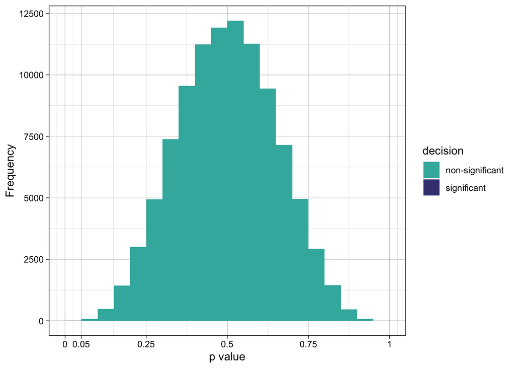

```r
tibble(p = rbeta(n = 100000, shape1 = 5, shape2 = 5)) |>
  plot_p_values()
```

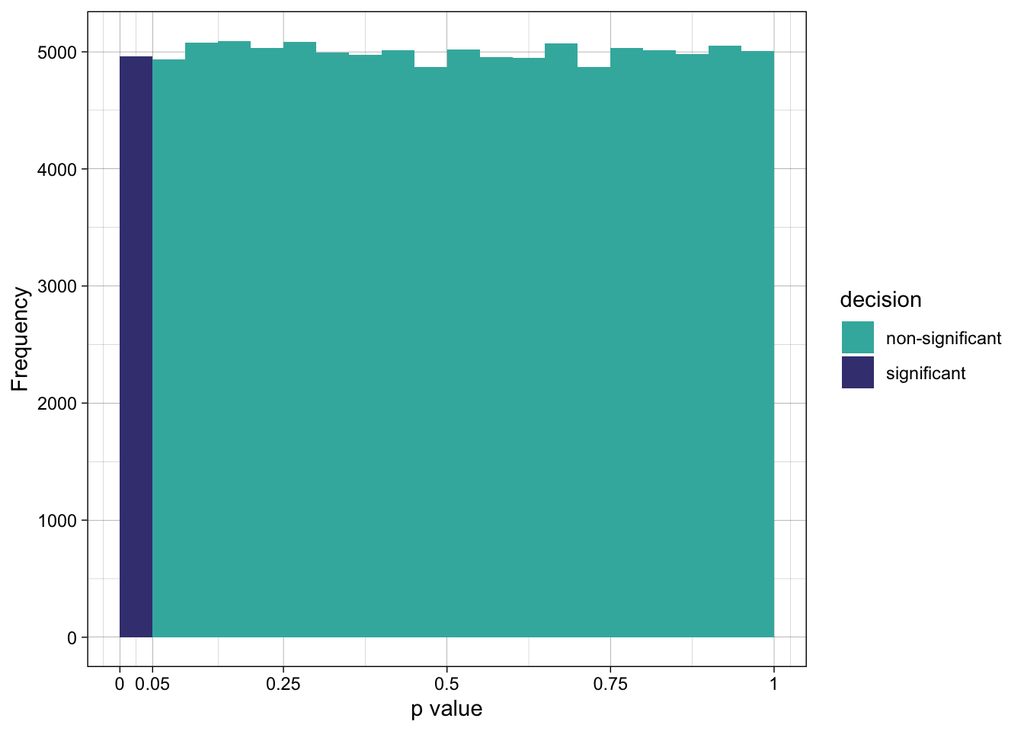

```r
tibble(p = rbeta(n = 100000, shape1 = 1, shape2 = 1)) |>
  plot_p_values()
```

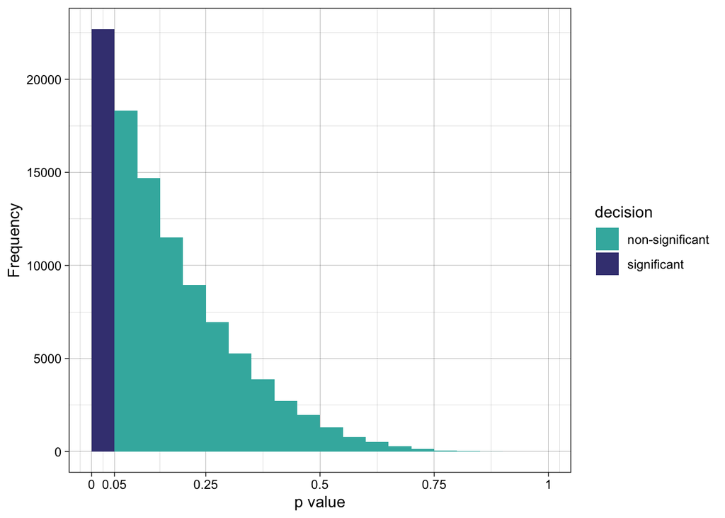

```r
tibble(p = rbeta(n = 100000, shape1 = 1, shape2 = 5)) |>
  plot_p_values()
```

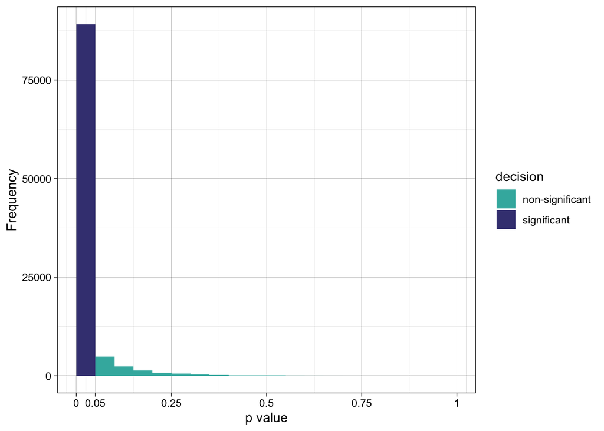

```r
tibble(p = rbeta(n = 100000, shape1 = 0.1, shape2 = 5)) |>
  plot_p_values()
```

- Again, these are not real *p* values, just data sampled from a Beta distribution.

# The distributions of *p* values

Let’s use (a) our understanding of how to construct a simulation [from lesson 2] and (b) our function to plot data that are (or look like) *p* values to understand how *p* values are distributed.

## Simulate

The code for this simulation is copied from lesson 2 with few modifications.

```r
# remove all objects from environment ----
#rm(list = ls())


# dependencies ----
# repeated here for the sake of completeness

library(tidyr)
library(dplyr)
library(purrr)
library(ggplot2)
library(knitr)
library(kableExtra)
library(janitor)


# set the seed ----
# for the pseudo random number generator to make results reproducible
set.seed(123)


# define data generating function ----
generate_data <- function(n_control,
                          n_intervention,
                          mean_control,
                          mean_intervention,
                          sd_control,
                          sd_intervention) {

  data_control <-
    tibble(condition = "control",
           score = rnorm(n = n_control, mean = mean_control, sd = sd_control))

  data_intervention <-
    tibble(condition = "intervention",
           score = rnorm(n = n_intervention, mean = mean_intervention, sd = sd_intervention))

  data <- bind_rows(data_control,
                    data_intervention)

  return(data)
}


# define data analysis function ----
analyse_data <- function(data) {

  res_t_test <- t.test(formula = score ~ condition,
                       data = data,
                       var.equal = FALSE,
                       alternative = "two.sided")

  res <- tibble(p = res_t_test$p.value)

  return(res)
}


# define experiment parameters ----
experiment_parameters_grid <- expand_grid(
  n_control = 50,
  n_intervention = 50,
  mean_control = 0,
  mean_intervention = c(0.0, 0.1, 0.2, 0.5, 0.8, 1.0), # only this differs meaningfully from the simulation in lesson 2: simulate data for a true effect size of 0 (null) and very small, small, medium, large, and very large Cohen's d (alternative)
  sd_control = 1,
  sd_intervention = 1,
  iteration = 1:10000
)


# run simulation ----
simulation <-
  # using the experiment parameters
  experiment_parameters_grid |>

  # generate data using the data generating function and the parameters relevant to data generation
  mutate(generated_data = pmap(list(n_control,
                                    n_intervention,
                                    mean_control,
                                    mean_intervention,
                                    sd_control,
                                    sd_intervention),
                               generate_data)) |>

  # apply the analysis function to the generated data using the parameters relevant to analysis
  mutate(analysis_results = pmap(list(generated_data),
                                 analyse_data))


# summarise simulation results over the iterations ----
simulation_reshaped <- simulation |>
  # convert `analysis_results` nested-data-frame column to regular columns in the df. in this case, the p value.
  unnest(analysis_results) |>
  # label the true effect value
  mutate(true_effect = paste("Cohen's d =", mean_intervention))
```

Results will be plotted in the next chunks.

## Under the null hypothesis

I.e., the data generation (population) is an effect of zero.

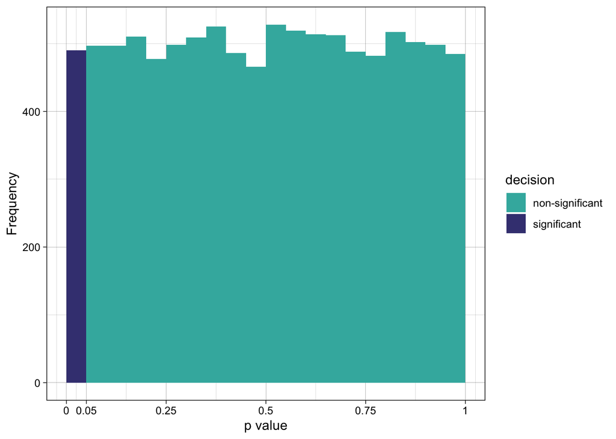

```r
simulation_reshaped |>
  # using only the iterations where the population effect was from a true null population
  filter(true_effect == "Cohen's d = 0") |>
  # plot using our function
  plot_p_values()
```

```r
simulation_reshaped |>
  filter(true_effect == "Cohen's d = 0") |>
  summarize(false_positive_rate__aka_alpha = mean(p < .05)) |>
  mutate_if(is.numeric, janitor::round_half_up, digits = 2)
```

```
## # A tibble: 1 × 1
##   false_positive_rate__aka_alpha
##                            <dbl>
## 1                           0.05
```

## Under the alternative hypothesis

I.e., the data generation (population) is a non-zero effect.

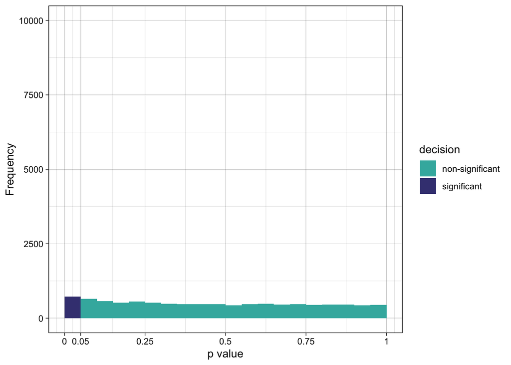

```r
simulation_reshaped |>
  filter(true_effect == "Cohen's d = 0.1") |>
  plot_p_values() +
  coord_cartesian(ylim = c(0, 10000))
```

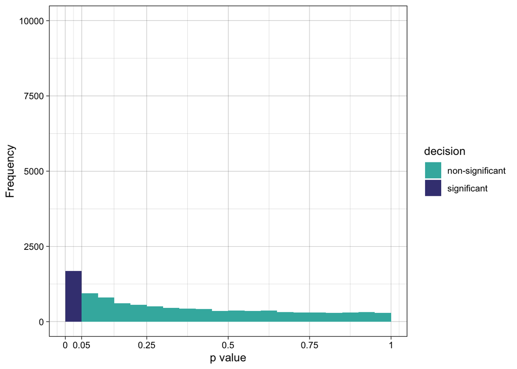

```r
simulation_reshaped |>
  filter(true_effect == "Cohen's d = 0.2") |>
  plot_p_values() +
  coord_cartesian(ylim = c(0, 10000))
```

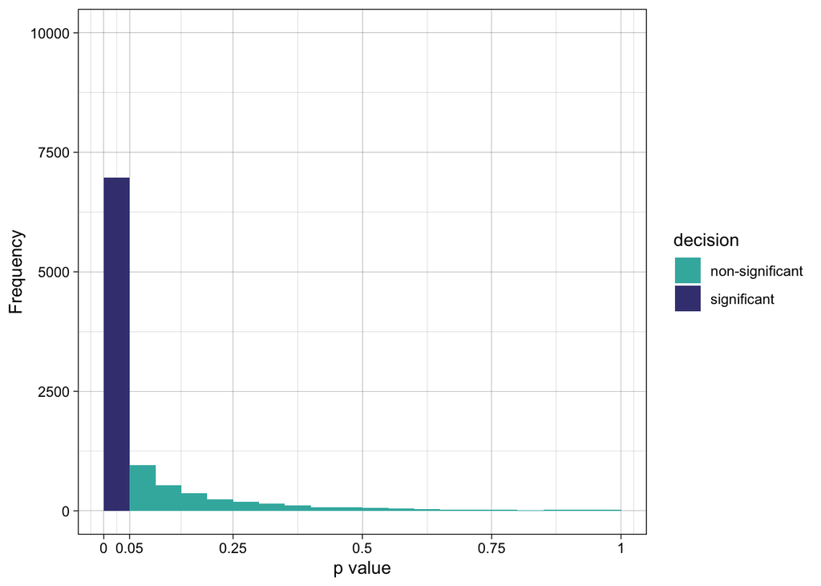

```r
simulation_reshaped |>
  filter(true_effect == "Cohen's d = 0.5") |>
  plot_p_values() +
  coord_cartesian(ylim = c(0, 10000))
```

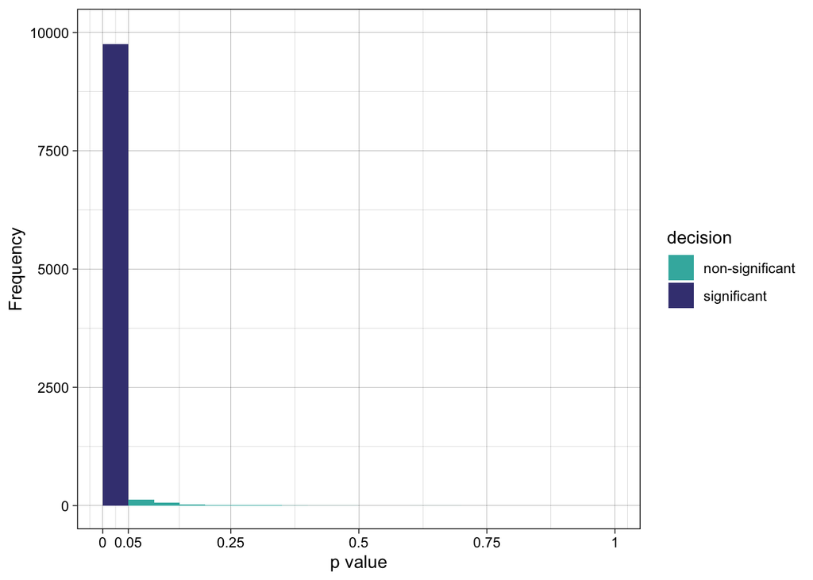

```r
simulation_reshaped |>
  filter(true_effect == "Cohen's d = 0.8") |>
  plot_p_values() +
  coord_cartesian(ylim = c(0, 10000))
```

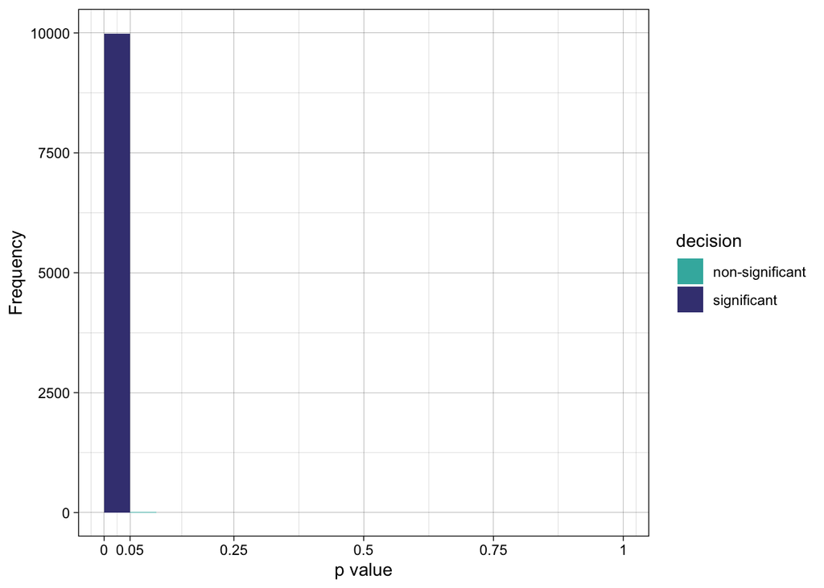

```r
simulation_reshaped |>
  filter(true_effect == "Cohen's d = 1") |>
  plot_p_values() +
  coord_cartesian(ylim = c(0, 10000))
```

```r
simulation_reshaped |>
  filter(true_effect == "Cohen's d = 0") |>
  summarize(false_positive_rate = mean(p < .05),
            .by = true_effect) |>
  mutate_if(is.numeric, janitor::round_half_up, digits = 2)
```

```
## # A tibble: 1 × 2
##   true_effect   false_positive_rate
##   <chr>                       <dbl>
## 1 Cohen's d = 0                0.05
```

```r
simulation_reshaped |>
  filter(true_effect != "Cohen's d = 0") |>
  summarize(true_positive_rate__aka_power = mean(p < .05),
            .by = true_effect) |>
  mutate_if(is.numeric, janitor::round_half_up, digits = 2)
```

```
## # A tibble: 5 × 2
##   true_effect     true_positive_rate__aka_power
##   <chr>                                   <dbl>
## 1 Cohen's d = 0.1                          0.07
## 2 Cohen's d = 0.2                          0.17
## 3 Cohen's d = 0.5                          0.7
## 4 Cohen's d = 0.8                          0.98
## 5 Cohen's d = 1                            1
```

- Why do we change the name of the variable in the table depending on the value true positive rate? Are you able to draw a 2X2 contingency table / confusion matrix that explains the difference between the different names?

# Dance of the *p* values

Let’s look at the data a different way to understand what we mean by “*p* values are uniformly distributed under the null hypothesis”.

Uniform distributions mean that all variables in the range are just as likely to occur.

For *p* values, this means that *p* values will dance back and forth between 0 and 1 between a studies where the null hypothesis is true (population effect is zero). I illustrate this blow by `filter()`-ing only the true effect of 0 conditions, and taking the first 150 iterations. You can see that between the iterations from left to right, which represent independent experiments here, there is no pattern among the *p* values. Despite the true effect being zero, a statistically significant result is still found sometimes, because values of p = .01, .02, .03, .04 are just as probable as .48 or .97 or any other.

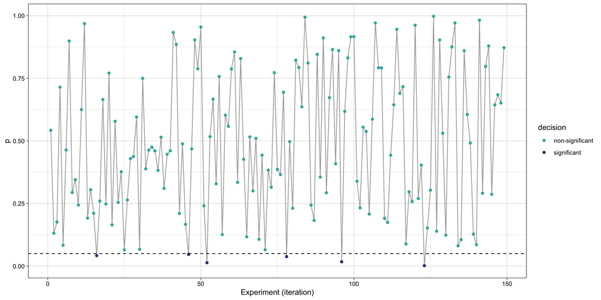

```r
simulation_reshaped |>
  filter(true_effect == "Cohen's d = 0") |>
  filter(iteration < 150) |>
  mutate(decision = ifelse(p < .05, "significant", "non-significant")) |>
  ggplot(aes(iteration, p)) +
  geom_line(color = "darkgrey") +
  geom_point(aes(color = decision)) +
  scale_color_viridis_d(option = "mako", begin = 0.3, end = 0.7, direction = -1) +
  theme_linedraw() +
  geom_hline(yintercept = 0.05, linetype = "dashed") +
  xlab("Experiment (iteration)")
```

# Diagnosticity of a given *p* value

Of course, when you read the literature you don’t have the advantage of knowing whether the effect being studied is real or not. Instead, it contains a mix or null and non-null effects - even when there is absolutely no *p*-hacking or publication bias.

This simulation assumes a range of true effects ranging from null to medium, and an unknown mix of null and non-null effects. No *p*-hacking or publication bias involved - we’ll come to this in a future lesson. There’s also no false positives due to violation of assumptions.

**Re-run these chunks yourself a few times and see if you can guess from looking at the first plot what the second plot will be made up of. Eg., are most of the significant results true positives (non-null effects) or false positives? Are most of the non-significant results true null effects, or false-negatives?**

Remember that as well as assuming no *p*-hacking or publication bias, they also assume all assumptions have been met. False positive rates go up if any of these are violated.

How the simulations are structured:

- Create a literature of 100 studies, studying different effects in the same broad domain.
- In this literature, an unknown number of studies (k_null) represent true null effects. This is done by sampling between 0 and 100 studies from the our existing simulations with a true effect of 0. The remaining number of studies (k_nonnull) represent non-null effects of various sizes from very small to medium
- The results from all the studies are then plotted together making only a significant vs. non-significant distinction.

**Here, as in the real world, our job is to judge the findings in a given literature only from the visible/published results, without ever having access to their true status. How easy do you find it to whether a given literature contains mostly real or null effects?**

```r
k_null <- runif(n = 1, min = 0, max = 100) |> round(0)
k_non_null <- 100 - k_null

# simulate published literature by sampling from the existing simulation iterations
unbiased_literature <-
  bind_rows(
    simulation_reshaped |>
      filter(true_effect == "Cohen's d = 0") |>
      sample_n(k_null),
    simulation_reshaped |>
      filter(true_effect %in% c("Cohen's d = 0.1", "Cohen's d = 0.2", "Cohen's d = 0.5")) |>
      sample_n(k_non_null)
  ) |>
  mutate(truth_vs_decision = case_when(true_effect == "Cohen's d = 0" & p >= .05 ~ "True negatives",
                                       true_effect == "Cohen's d = 0" & p <  .05 ~ "False positives",
                                       true_effect != "Cohen's d = 0" & p >= .05 ~ "False negatives",
                                       true_effect != "Cohen's d = 0" & p <  .05 ~ "True positives"))
```

## Published literature

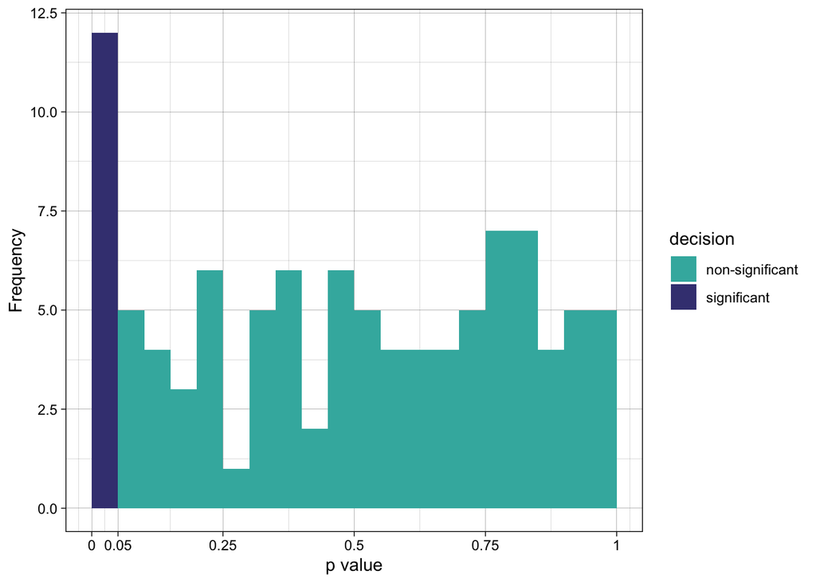

```r
unbiased_literature |>
  plot_p_values()
```

## True effects underlying the published literature

(unknowable in the real world)

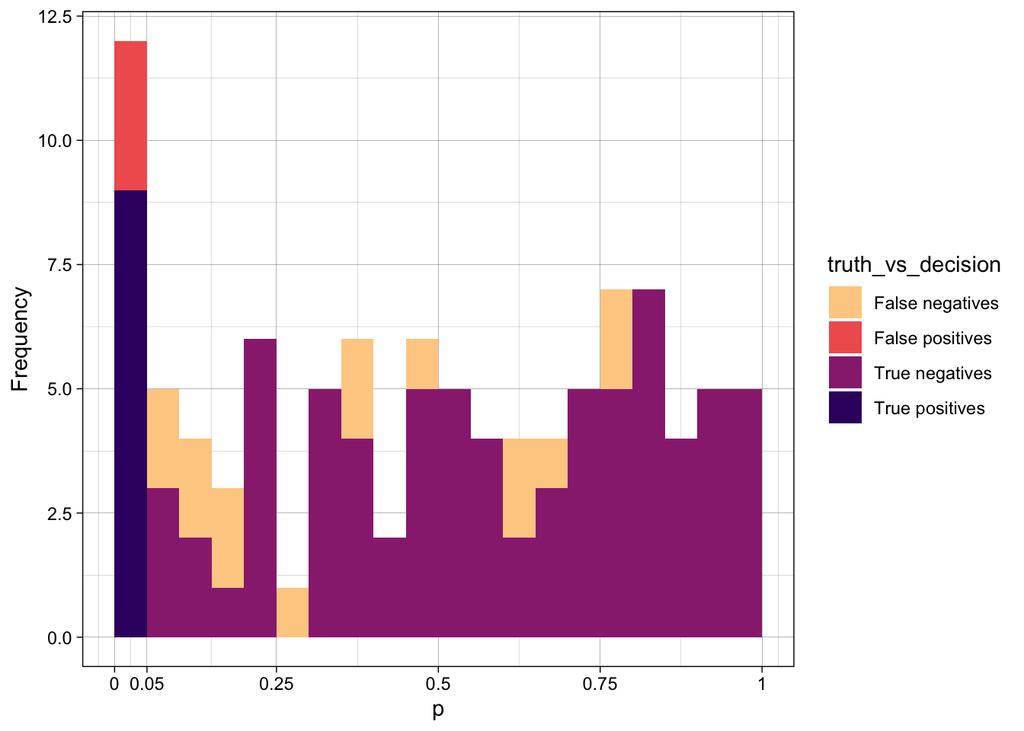

```r
unbiased_literature |>
  ggplot(aes(p, fill = truth_vs_decision)) +
  geom_histogram(binwidth = 0.05, boundary = 0) +
  scale_fill_viridis_d(option = "magma", begin = 0.2, end = 0.9, direction = -1) +
  scale_x_continuous(labels = c(0, 0.05, 0.25, 0.50, 0.75, 1.0),
                     breaks = c(0, 0.05, 0.25, 0.50, 0.75, 1.0),
                     limits = c(0, 1)) +
  theme_linedraw() +
  ylab("Frequency")
```

```r
unbiased_literature |>
  count(truth_vs_decision) |>
  pivot_wider(names_from = truth_vs_decision,
              values_from = n) |>
  mutate(`False discovery rate` = round_half_up(`False positives` / (`False positives` + `True positives`), digits = 2),
         `Missed discovery rate` = round_half_up(`False negatives` / (`False negatives` + `True negatives`), digits = 2)) |>
  #pivot_longer(cols = everything()) |>
  #mutate_if(is.numeric, janitor::round_half_up, digits = 2) |>
  kable() |>
  kable_classic(full_width = FALSE)
```

| False negatives | False positives | True negatives | True positives | False discovery rate | Missed discovery rate |
| --- | --- | --- | --- | --- | --- |
| 15 | 3 | 73 | 9 | 0.25 | 0.17 |

## Single study from the published literature

The difficulty of using p values to diagnose the true population effect can also be illustrated, perhaps more easily, by using (a) single studies, where (b) the true effect is either null or small.

```r
k_null <- 50
k_non_null <- 50

unbiased_literature_2 <-
  bind_rows(
    simulation_reshaped |>
      filter(true_effect == "Cohen's d = 0") |>
      sample_n(k_null),
    simulation_reshaped |>
      filter(true_effect == "Cohen's d = 0.1") |> # "Cohen's d = 0.1" for low power, "Cohen's d = 1" for very high power.
      sample_n(k_non_null)
  ) |>
  mutate(truth_vs_decision = case_when(true_effect == "Cohen's d = 0" & p >= .05 ~ "True negatives",
                                       true_effect == "Cohen's d = 0" & p <  .05 ~ "False positives",
                                       true_effect != "Cohen's d = 0" & p >= .05 ~ "False negatives",
                                       true_effect != "Cohen's d = 0" & p <  .05 ~ "True positives"))
```

Run the following chunk yourself. Using just the *p* value, decide if you think the population effect is null (d = 0.0) or non null (d = 0.1).

```r
random_study <- unbiased_literature_2 |>
  sample_n(size = 1)

paste("p =", round_half_up(random_study$p, 3))
```

```
## [1] "p = 0.774"
```

Then run the next chunk to see if you were right.

```r
paste("Population effect:", random_study$true_effect)
```

```
## [1] "Population effect: Cohen's d = 0"
```

```r
random_study$truth_vs_decision
```

```
## [1] "True negatives"
```

You can repeat the above two steps lots of times to check your intuitions.

Remember that the decision accuracy (true positive, true negative, false positive, false negative) is **unknowable** in the real world when doing substantive research - all you can know is an estimate of your test’s power (i.e., 1 - $\beta$) and your false positive rate (i.e., $\alpha$).